# Relatório Municipal de Indicadores 2023

Belém, Pará

SAGICAD e SNAS / MDS

# 1 ID CRAS: Indice de Desenvolvimento do CRAS

O ID CRAS é um indicador composto por três dimensões. Cada dimensão possui uma nota na qual quanto mais próxima de 5, melhor o índice e, do contrário, insatisfatório.

O Gráfico 1 mostra a evolução das médias do ID CRAS ao longo dos anos no município de Belém, Pará.

Gráfico 1. Evolução das médias do ID CRAS, 2014 a 2023: Belém, Pará

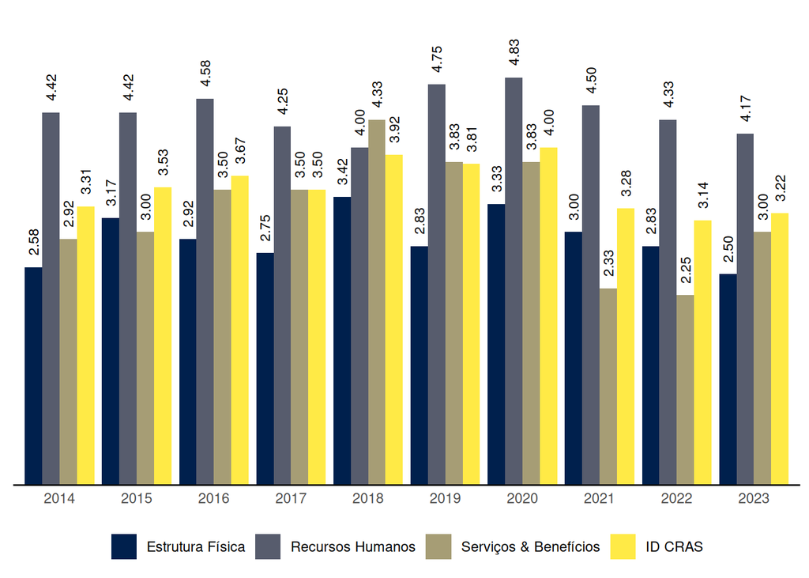

Gráfico 2. Quantidade de CRAS em cada nível de ID, 2023: Belém, Pará

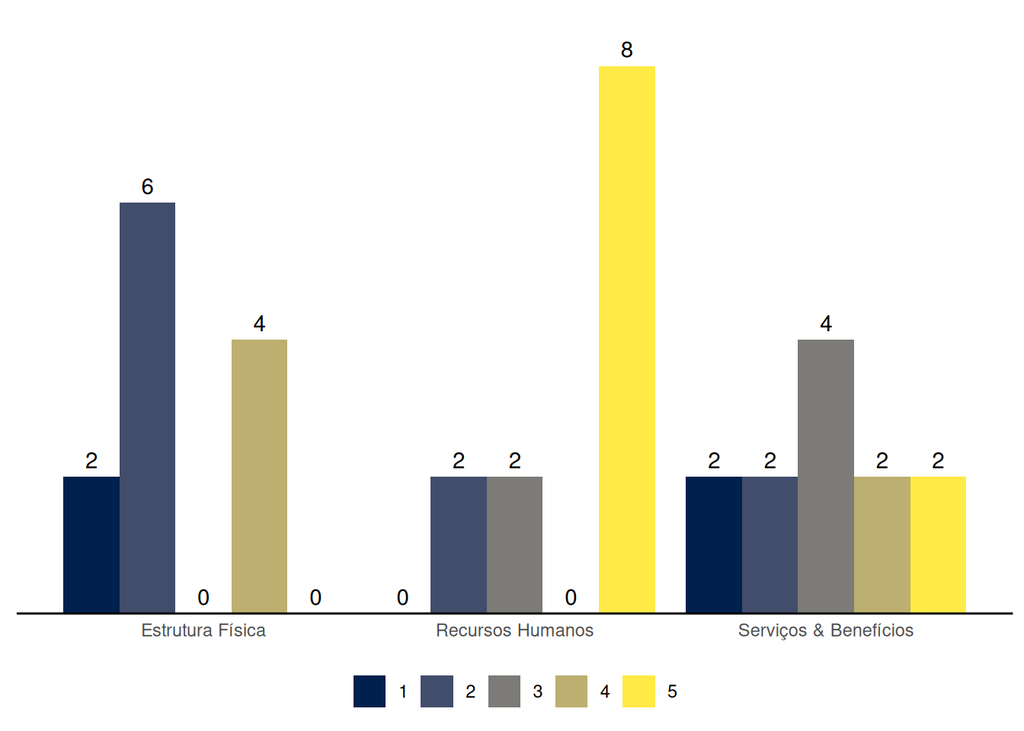

Tabela 1. Quantidade de CRAS em 2023 no município de Belém por capacidade de referenciamento.

Quantidade de CRAS em 2023 no município de Belém por capacidade de referenciamento.

| Capacidade de até: | Quantidade |
| --- | --- |
| 2.500 famílias referenciadas | 0 |
| 3.500 famílias referenciadas | 0 |
| 5.000 famílias referenciadas | 12 |

As seções a seguir apresentam os resultados do município de Belém em cada uma das dimensões do ID CRAS, bem como os requisitos para se alcançar os níveis superiores.

## 1.1 ID CRAS: Dimensão Estrutura Física

### 1.1.1 CRAS com capacidade de referenciamento para até 2.500 ou 3.500 famílias

Belém não tem CRAS com capacidade de referenciamento para até 2.500 ou 3.500 famílias.

### 1.1.2 CRAS com capacidade de referenciamento para até 5.000 famílias

Na dimensão Estrutura Física, o nível de ID dos CRAS com capacidade de referenciamento para até 5.000 famílias no município de Belém varia de 1 a 4.

O CRAS de **nível 1**, com capacidade de referenciamento para até 5.000 famílias, na dimensão Estrutura Física:

- Possui **menos de 3 salas de atendimento**; ou
- **Não possui banheiro**; ou
- Funciona em **prédio compartilhado com ONG, ou com compartilhamento de todas as salas de atendimento**.

Para alcançar o **nível 2** na dimensão Estrutura Física, o CRAS com capacidade de referenciamento para até 5.000 famílias precisa:

- Possuir no mínimo **3 salas de atendimento**; e
- Possuir pelo menos **1 banheiro**.

Para alcançar o **nível 3** na dimensão Estrutura Física, o CRAS com capacidade de referenciamento para até 5.000 famílias precisa, além dos requisitos do nível 2:

- Possuir **recepção**; e
- Possuir **pelo menos 1 das salas de atendimento com capacidade para 15 ou mais pessoas**; e
- Possuir **acessibiliadade, ao menos parcial**.

Para alcançar o **nível 4** na dimensão Estrutura Física, o CRAS com capacidade de referenciamento para até 5.000 famílias precisa, além dos resquisitos do nível 3:

- Possuir no mínimo **4 salas de atendimento** (sendo **pelo menos 1 com capacidade para 15 ou mais pessoas**); e
- Possuir no mínimo **2 banheiros**; e
- Possuir **pelo menos 2 computadores conectados à internet**.

Para alcançar o **nível 5** na dimensão Estrutura Física, o CRAS com capacidade de referenciamento para até 5.000 famílias precisa, além dos requisitos do nível 4:

- Possuir no mínimo **1 sala administrativa**; e
- Possuir **acessibilidade**; e
- Possuir conjunto de equipamentos que inclua, no mínimo: **3 computadores conectados à internet, impressora, telefone e veículo exclusivo ou compartilhado**.

## 1.2 ID CRAS: Dimensão Recursos Humanos

### 1.2.1 CRAS com capacidade de referenciamento para até 2.500 famílias

Belém não tem CRAS com capacidade de referenciamento para até 2.500 famílias.

### 1.2.2 CRAS com capacidade de referenciamento para até 3.500 famílias

Belém não tem CRAS com capacidade de referenciamento para até 3.500 famílias.

### 1.2.3 CRAS com capacidade de referenciamento para até 5.000 famílias

Na dimensão Recursos Humanos, o nível de ID dos CRAS com capacidade de referenciamento para até 5.000 famílias no município de Belém varia de 2 a 5.

O CRAS de **nível 2**, com capacidade de referenciamento para até 5.000 famílias, na dimensão Recursos Humanos:

- Possui no mínimo **6** profissionais, sendo pelo menos **3** com nível superior; e
- Possui pelo menos **1 Assistente Social ou 1 Psicólogo**.

Para alcançar o **nível 3** na dimensão Recursos Humanos, o CRAS com capacidade de referenciamento para até 5.000 famílias precisa, além dos requisitos do nível 2:

- Possuir no mínimo **7** (9, se EV) profissionais, sendo pelo menos **4** (6, se EV) com nível superior; e
- Possuir no mínimo **2 Assistentes Sociais** (3, se EV).

Para alcançar o **nível 4** na dimensão Recursos Humanos, o CRAS com capacidade de referenciamento para até 5.000 famílias precisa, além dos resquisitos do nível 3:

- Possuir no mínimo **7** (10, se EV) profissionais, sendo pelo menos **5** (7, se EV) com nível superior; e
- Possuir no mínimo **1 Psicólogo**; e
- Possuir **coordenador** com nível superior.

Para alcançar o **nível 5** na dimensão Recursos Humanos, o CRAS com capacidade de referenciamento para até 5.000 famílias precisa, além dos requisitos do nível 4:

- Possuir no mínimo **9** (13, se EV) **profissionais** (sendo pelo menos **5** (7, se EV) com **nível superior**); e
- Possuir no mínimo **2** profissionais de nível superior com **vínculo estatutário ou empregado público celetista**.

## 1.3 ID CRAS: Dimensão Serviços & Benefícios

Na dimensão Serviços & Benefícios, o nível de ID dos CRAS no município de Belém varia de 1 a 5.

O CRAS de **nível 1** na dimensão Serviços & Benefícios em município de porte Metrópole:

- **Não realiza** alguma(s) das seguintes atividades essenciais do PAIF: **acompanhamento de famílias, e/ou grupo/oficina com famílias, e/ou visitas domiciliares, e/ou orientação**; ou
- Possui **articulação frágil ou inexistente** com os Serviços de Educação, com os Serviços de Saúde e com os CREAS; ou
- Não possui profissionais de Serviço Social nem de Psicologia.

Para alcançar o **nível 2** na dimensão Serviços & Benefícios, o CRAS em município de porte Metrópole precisa:

- **Executar o PAIF**, realizando no mínimo as seguintes atividades: **acompanhamento de famílias, grupo/oficina com famílias e visitas domiciliares**; e
- Possuir **forte articulação com pelo menos um dos seguintes Serviços: Serviços de Educação, Serviços de Saúde e CREAS**.

Para alcançar o **nível 3** na dimensão Serviços & Benefícios, o CRAS em município de porte Metrópole precisa, além dos requisitos do nível 2:

- **Executar o PAIF** realizando **orientação/acompanhamento para inserção no BPC**, além das atividades exigidas para o nível 2; e
- Possuir oferta de Serviço de Convivência **pelo menos para um ciclo de vida** (oferta direta do CRAS ou por meio de unidades a ele referenciadas); e
- Possuir **forte articulação com o(s) CREAS e com os Serviços de Educação e Saúde** no território.

Para alcançar o **nível 4** na dimensão Serviços & Benefícios, o CRAS em município de porte Metrópole precisa, além dos requisitos do nível 3:

- Ter **quantidade média de famílias em acompanhamento no mês, dividida pela equipe técnica** (Assistentes Sociais e Psicólogos) não inferior a 20 nem superior a 100; e
- **Executar o PAIF** realizando **palestras, campanhas ou eventos comunitários e acompanhamento dos encaminhamentos realizados**, além das atividades exigidas para o nível 3; e
- Possuir oferta de Serviço de Convivência **para no mínimo dois ciclos de vida** (oferta direta do CRAS ou por meio de unidades a ele referenciadas); e
- **Funcionar** no mínimo **5 dias** por semana e **40 horas** semanais.

Para alcançar o **nível 5** na dimensão Serviços & Benefícios, o CRAS em município de porte Metrópole precisa, além dos requisitos do nível 4:

- Possuir profissionais de Serviço Social e de Psicologia; e
- Possuir oferta de Serviço de Convivência, **para no mínimo três ciclos de vida** (oferta direta do CRAS ou por meio de unidades a ele referenciadas); e
- **Realizar no próprio CRAS o cadastramento/atualização cadastral do CadÚnico**, sem utilizar para isso os profissionais de nível superior do PAIF.

# 2 ID CREAS: Indice de Desenvolvimento do CREAS

O ID CREAS é um indicador composto por três dimensões. Cada dimensão possui uma nota na qual quanto mais próxima de 5, melhor o índice e, do contrário, insatisfatório.

O Gráfico 3 mostra a evolução das médias do ID CREAS ao longo dos anos no município de Belém, Pará.

Gráfico 3. Evolução das médias do ID CREAS, 2014 a 2023: Belém, Pará

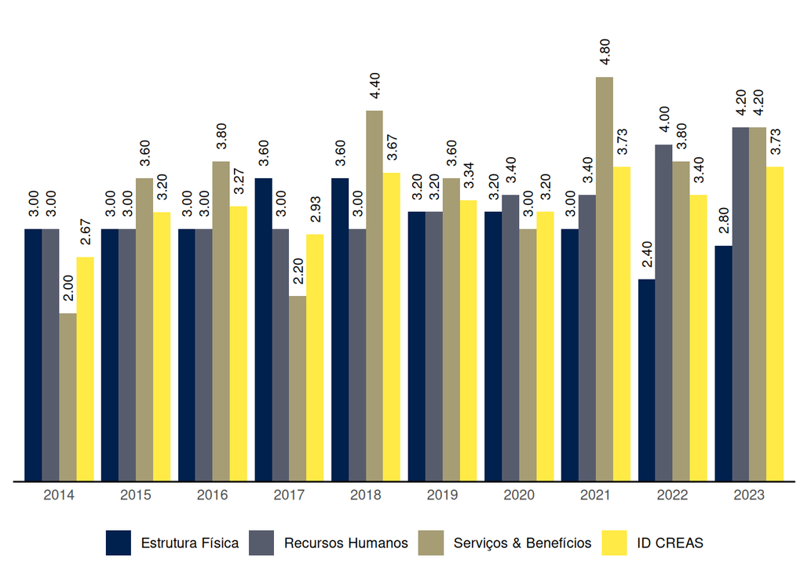

Gráfico 4. Quantidade de CREAS em cada nível de ID, 2023: Belém, Pará

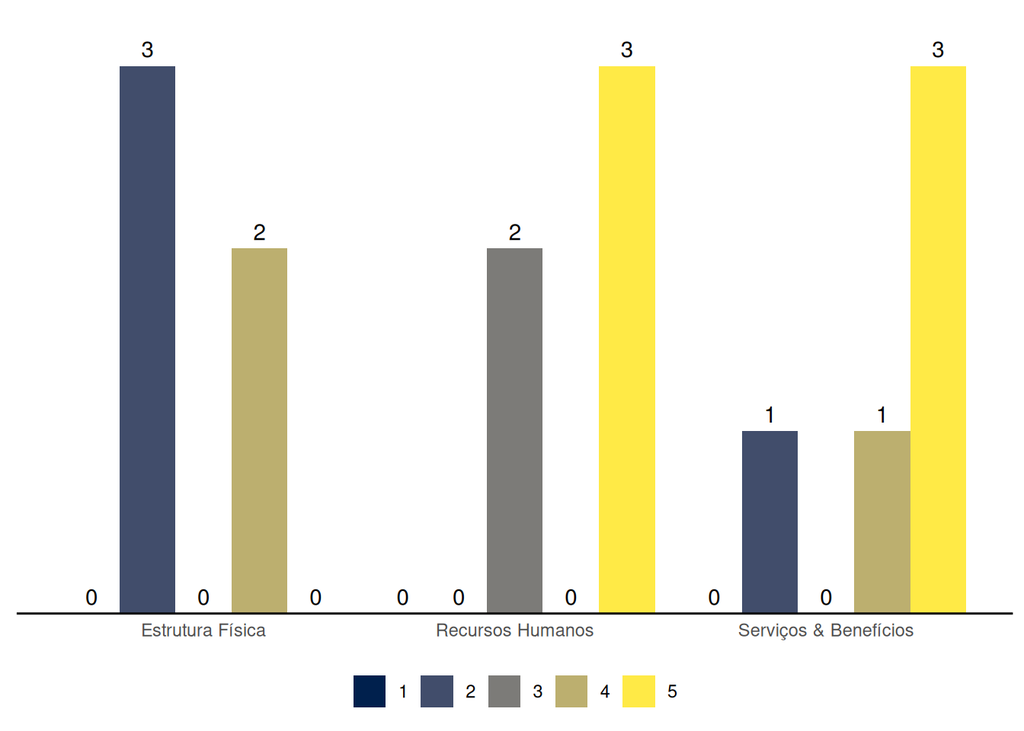

As seções a seguir apresentam os resultados do município de Belém em cada uma das dimensões do ID CREAS, bem como os requisitos para se alcançar os níveis superiores.

## 2.1 ID CREAS: Dimensão Estrutura Física

Na dimensão Estrutura Física, o nível de ID dos CREAS no município de Belém varia de 2 a 4.

O CREAS de **nível 2** na dimensão Estrutura Física em município de porte Metrópole:

- Possui no mínimo 3 salas (atendimento e/ou administrativa); e
- Possui no mínimo 1 banheiro.

Para alcançar o **nível 3** na dimensão Estrutura Física, o CREAS em município de porte Metrópole precisa, além dos requisitos do nível 2:

- Possuir recepção; e
- Possuir acessibilidade, ao menos parcial.

Para alcançar o **nível 4** na dimensão Estrutura Física, o CREAS em município de porte Metrópole precisa, além dos requisitos do nível 3:

- Possuir no mínimo 2 banheiros; e
- Possuir 1 ou mais computadores com Internet; e
- Possuir veículo próprio ou compartilhado; e
- Possuir 5 salas ou mais para atendimento.

Para alcançar o **nível 5** na dimensão Estrutura Física, o CREAS em município de porte Metrópole precisa, além dos requisitos do nível 4:

- Possuir 1 ou mais sala Administrativa; e
- Possuir kit equipamento: Telefone, Impressora, 2 ou mais computadores com Internet, além de Veículo próprio ou compartilhado; e
- Possuir acessibilidade (com ou sem ABNT); e
- Possuir pelo menos 1 das salas para atendimento com capacidade para 15 ou mais pessoas.

## 2.2 ID CREAS: Dimensão Recursos Humanos

Na dimensão Recursos Humanos, o nível de ID dos CREAS no município de Belém varia de 3 a 5.

O CREAS de **nível 3** na dimensão Recursos Humanos em município de porte Metrópole:

- Possui Coordenador com nível superior; e
- Tem quantidade total de trabalhadores (nível superior e médio) maior ou igual a 10, sendo no mínimo 5 deles de nível superior; e
- Tem quantidade total de Assistentes Sociais, mais Psicólogos, maior ou igual a 4, sendo obrigatória a presença de profissionais destas duas áreas.

Para alcançar o **nível 4** na dimensão Recursos Humanos, o CREAS em município de porte Metrópole precisa, além dos requisitos do nível 3:

- Possuir no mínimo 1 Advogado; e
- Ter no mínimo 6 trabalhadores de nível superior.

Para alcançar o **nível 5** na dimensão Recursos Humanos, o CREAS em município de porte Metrópole precisa, além dos requisitos do nível 4:

- Ter quantidade total de trabalhadores (nível superior e médio) maior ou igual a 14, sendo no mínimo 7 deles de nível superior; e
- Possuir no mínimo 2 Assistentes Sociais; e
- Possuir no mínimo 2 Psicólogos; e
- Possuir no mínimo 2 trabalhadores de nível superior com vínculo estatutário ou empregado público celetista.

## 2.3 ID CREAS: Dimensão Serviços & Benefícios

Na dimensão Serviços & Benefícios, o nível de ID dos CREAS no município de Belém varia de 2 a 5.

O CREAS de **nível 2** na dimensão Serviços & Benefícios em município de porte Metrópole:

- Oferta o PAEFI assegurando a realização, pelo menos, das seguintes atividades: Entrevistas de acolhida para avaliação inicial dos casos, Atendimento psicossocial individual/familiar, Visitas domiciliares e Elaboração de relatórios técnicos sobre casos em acompanhamento; e
- Possui forte articulação com o CRAS.

Para alcançar o **nível 3** na dimensão Serviços & Benefícios, o CREAS em município de porte Metrópole precisa, além dos requisitos do nível 2:

- Ofertar o PAEFI assegurando a realização da Construção de Plano Individual e/ou Familiar de atendimento (além da realização das atividades exigidas no nível 2); e
- Possuir forte articulação com o Conselho Tutelar; e
- Ofertar atendimento para variadas situações de violência ou violação de direitos e para os diferentes ciclos de vida; e
- Ofertar o Serviço de MSE.

Para alcançar o **nível 4** na dimensão Serviços & Benefícios, o CREAS em município de porte Metrópole precisa, além dos requisitos do nível 3:

- Ofertar o PAEFI assegurando a realização da atividade de Atendimento psicossocial em grupo (além da realização das atividades exigidas no nível 3); e
- Ter quantidade média de casos em acompanhamento no mês, dividida pela equipe técnica (AS + PSI) menor ou igual a 50 casos; e
- Ofertar o Serviço de MSE assegurando a elaboração do Plano Individual de Atendimento (PIA) do adolescente; e
- Ofertar o Serviço de Abordagem ou ter o Serviço referenciado.

Para alcançar o **nível 5** na dimensão Serviços & Benefícios, o CREAS em município de porte Metrópole precisa, além dos requisitos do nível 4:

- Ofertar o PAEFI assegurando a realização de Ações de mobilização e sensibilização para o enfrentamento das situações de violação de direitos (além da realização das atividades exigidas no nível 4); e
- Ter quantidade média de casos em acompanhamento no mês, dividida pela equipe técnica (AS + PSI) menor ou igual a 30 casos; e
- Possuir Assistente Social e Psicólogo; e
- Funcionar no mínimo 5 dias por semana e 40 horas semanais; e
- Ofertar o Serviço de MSE assegurando a realização, pelo menos, das seguintes atividades, além das atividades exigidas no nível 4: Ofertar LA e PSC; Acompanhamento de LA e PSC, com frequência de atendimento semanal ou quinzenal e Atendimento do adolescente em grupos; e
- Manter forte articulação com Serviços de Acolhimento.

# 3 ID Conselho: Indice de Desenvolvimento dos Conselhos de Assistência Social

O ID Conselho é indicador desenvolvimento com o objetivo de avaliar o controle social no SUAS. Ele possui três dimensões. Cada dimensão possui uma nota na qual quanto mais próxima de 5, melhor o índice e, do contrário, insatisfatório.

O Gráfico 5 mostra a evolução das médias do ID Conselho ao longo dos anos no município de Belém, Pará.

Gráfico 5. Evolução das médias do ID Conselho, 2014 a 2023: Belém, Pará

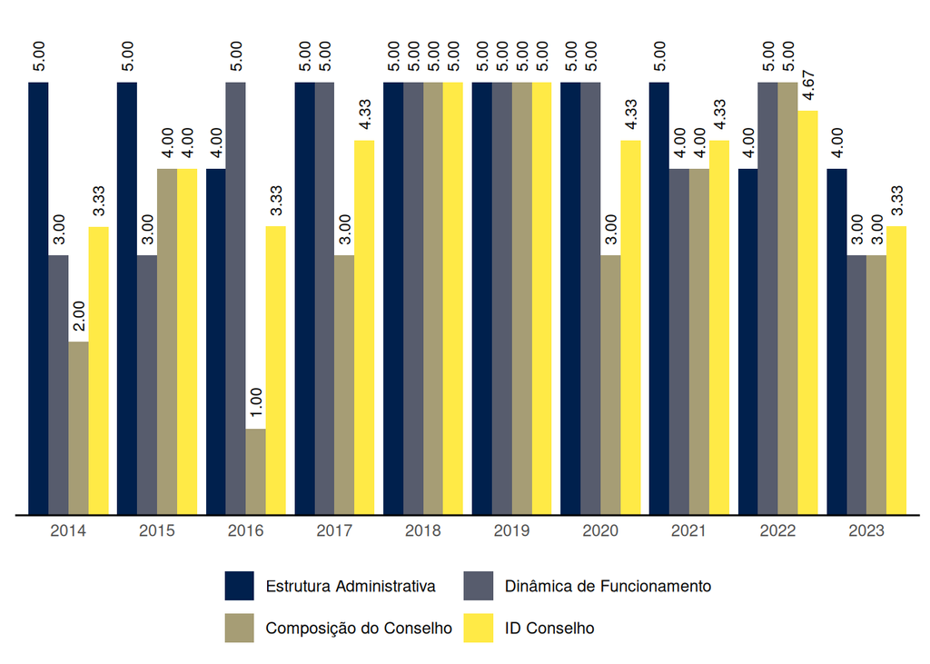

As seções a seguir apresentam os resultados do município de Belém em cada uma das dimensões do ID Conselho, bem como os requisitos para se alcançar os níveis superiores.

## 3.1 ID Conselho: Dimensão Estrutura Administrativa

Na dimensão Estrutura Administrativa, o nível de ID do Conselho no município de Belém é 4.

O Conselho de **nível 4** na dimensão Estrutura Administrativa em município de porte Metrópole:

- Possui previsão de recursos na Lei Orçamentária Anual ou utiliza para as despesas de seu funcionamento o mínimo de 3% do IGD; e
- Possui Secretaria Executiva; e
- Possui um ou mais computadores conectados à internet; e
- Possui telefone de uso exclusivo ou compartilhado; e
- Possui uma ou mais salas de uso exclusivo.

Para alcançar o **nível 5** na dimensão Estrutura Administrativa, o Conselho em município de porte Metrópole precisa, além dos requisitos do nível 4:

- Possuir previsão de recursos específicos na Lei Orçamentária Anual; e
- Utilizar para as despesas de seu funcionamento o mínimo de 3% do IGD; e
- Ter veículo exclusivo ou compartilhado; e
- Possuir telefone de uso exclusivo do Conselho; e
- Que o Secretário Executivo seja exclusivo do Conselho de Assistência Social.

## 3.2 ID Conselho: Dimensão Dinâmica de Funcionamento

Na dimensão Dinâmica de Funcionamento, o nível de ID do Conselho no município de Belém é 3.

O Conselho de **nível 3** na dimensão Dinâmica de Funcionamento em município de porte Metrópole:

- Realizou 6 ou mais reuniões plenárias no ano anterior (ordinárias e extraordinárias); e
- Possui Regimento Interno; e
- Deliberou sobre o Plano de Assistência Social; e
- Acompanha o cumprimento de deliberações da Conferência Municipal.

Para alcançar o **nível 4** na dimensão Dinâmica de Funcionamento, o Conselho em município de porte Metrópole precisa, além dos requisitos do nível 3:

- Realizar 8 ou mais reuniões plenárias no ano anterior (ordinárias e extraordinárias); e
- Deliberar sobre o orçamento do executivo; e
- Ser instância de Controle Social do Bolsa Família.

## 3.3 ID Conselho: Dimensão Composição do Conselho

Na dimensão Composição do Conselho, o nível de ID do Conselho no município de Belém é 3.

O Conselho de **nível 3** na dimensão Composição do Conselho em município de porte Metrópole:

- Possui no mínimo 6 conselheiros titulares; e
- Possui pelo menos um conselheiro titular representante de usuários ou organização de usuários; e
- Possui pelo menos um conselheiro titular representante de trabalhadores do setor; e
- Possui alternância na presidência entre os representantes de governo e os representantes da sociedade civil.

Para alcançar o **nível 4** na dimensão Composição do Conselho, o Conselho em município de porte Metrópole precisa, além dos requisitos do nível 3:

- Possuir representantes da sociedade civil eleitos por assembleias constituídas para esse fim; e
- Possuir Presidente e Vice-Presidente eleitos em plenária; e
- Que o Conselheiro possa ser reconduzido uma única vez.